# 2.0. Probability

The underlying principle of Data Science is nothing but statistical mathematics and linear algebra. Often you will encounter situations, especially in Machine Learning, where you have to read some research paper which involves a lot of statistics and probability in order to understand a particular topic and so if you want to get better at Machine Learning, it's imperative to have a strong statistical understanding. This tutorial is about basics of probability which will build the base for probability distributions used in machine learning literature.

A **probability** is a quantitative measure of uncertainty—a number that conveys the strength of our belief in the occurrence of an uncertain event.

## Basic Definitions

**Set:** $A$ set is a collection of elements.

**Compliment of Set:** Given a set $A$, we may define its complement.The complement of set $A$ is the set containing all the elements in the universal set $S$ that are not members of set $A$. We denote the complement of $A$ by $A'$ or $\bar A$ or sometimes $A^c$. The set is often called “**not A**.”

**Intersection:** If $A$ and $B$ have some elements in common, we say they intersect. The intersection of $A$ and $B$, denoted $A \cap B$, is the set containing all elements that are members of both $A$ and $B$.

**Union:** When we want to consider all the elements of two sets A and B, we look at their union. The union of $A$ and $B$, denoted $A \cup B$, is the set containing all elements that are members of either $A$ or $B$ or both.

A Venn diagram is a schematic drawing of sets that demonstrates the relationships between different sets. Some examples of venn diagram are displayed below:

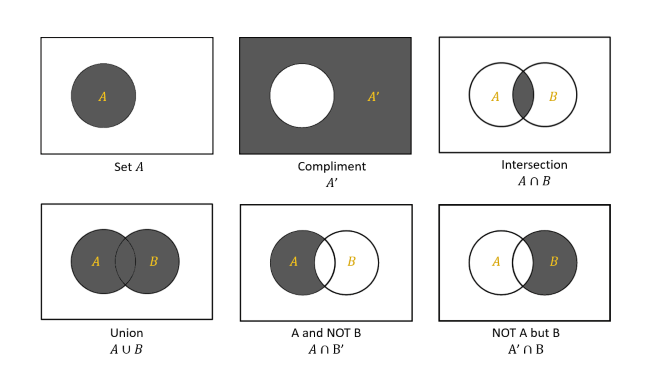

**Experiment:** An experiment is a process that leads to one of several possible outcomes. An outcome of an experiment is some observation or measurement.

**Sample Space:** The sample space is the universal set $S$ pertinent to a given experiment. The sample space is the set of all possible outcomes of an experiment.

**Event:** An event is a subset of a sample space. It is a set of basic outcomes. We say that the event occurs if the experiment gives rise to a basic outcome belonging to the event.

The formula we use in computing probabilities, assuming equal likelihood of all basic outcomes, is as follows:

### Probability of event $A$:

$$ P(A) = \frac {n(A)}{n(S)}$$

where,

$n(A)$ = the number of elements in the set of the event $A$

$n(S)$ = the number of elements in the sample space $S$

# 2.1. Basic rules of Probability

**Probability:** Probability is a measure of uncertainty. The probability of event $A$ is a numerical measure of the likelihood of the event’s occurring.

Probability obeys certain rules. The first rule sets the range of values that the probability measure may take.

**1. The Range of Values**

For any event $A$, the probability $P(A)$ satisfies $$0 \le P(A)\le 1$$

- When an event cannot occur, its probability is zero.
- Events that are certain to occur have probability 1.00

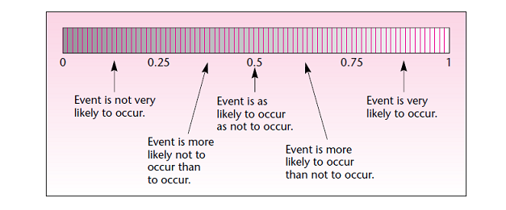

Within the range of values 0 to 1, the greater the probability, the more confidence we have in the occurrence of the event in question. A probability of 0.95 implies a very high confidence in the occurrence of the event. A probability of 0.80 implies a high confidence. When the probability is 0.5, the event is as likely to occur as it is not to occur. When the probability is 0.2, the event is not very likely to occur. When we assign a probability of 0.05, we believe the event is unlikely to occur, and so on.

The probability of entire sample space, i.e., $P(S)$ is always equal to 1.

**2. The Rule of Complements**

Our second rule for probability defines the probability of the complement of an event in terms of the probability of the original event. Recall that the complement of set $A$ is denoted by $\bar A$.

Probability of the complement: $$P(\bar A) = 1 - P(A)$$

**3. The Rule of Unions**

We now state a very important rule, the rule of unions. The rule of unions allows us to write the probability of the union of two events in terms of the probabilities of the two events and the probability of their intersection.

The rule of unions: $$P(A \cup B) = P(A) + P(B) - P(A \cap B)$$

The probability of the intersection of two events $P(A \cap B)$ is called their joint probability.

Consider the following example from a deck of cards, where we wish to find **Probability that a randomly drawn card is either a Jack or of Hearts.**

[figure not shown]

$P(Club) = \large {13 \over 52}$ $; P(Spade) = \large {13 \over 52}$ $;P(Hearts) = \large {13 \over 52}\;$$; P(Diamond) = \large {13 \over 52}$

$P(Ace) = \large {4 \over 52}$ $; P(Jack) = \large {4 \over 52}$ $;P(Queen) = \large {4 \over 52}$ $; P(King) = \large {4 \over 52}$

Observe that two events say,

- Event A : getting a Jack card
- Event B: getting a card of hearts

have an overlap (or intersection). Thus,

$$P(Jack \cup Hearts) = P(Jack) + P(Hearts) - P(Jack \cap Hearts) = {4 \over 52} + {13 \over 52} - {1 \over 52} = {4 \over 13}$$

```python
#find probability a randomly drawn card is either a card of Heart or a Jack

P_Jack = 4/52
P_Hearts = 13/52
P_Jack_n_Hearts = 1/52
P_Jack_or_Hearts = P_Jack + P_Hearts - P_Jack_n_Hearts

print(P_Jack_or_Hearts)
```

```
0.3076923076923077
```

### Mutually Exclusive Events

When the sets corresponding to two events are disjoint (i.e., have no intersection), the two events are called mutually exclusive.

For mutually exclusive events $A$ and $B$:

$$P(A \cap B) = 0$$

This fact gives us a special rule for unions of mutually exclusive events. Since the *probability of the intersection of the two events is zero*, there is no need to subtract $P(A \cap B)$ when the probability of the union of the two events is computed. Therefore,

For mutually exclusive events $A$ and $B$:

$$P(A \cup B) = P(A) + P(B)$$

Consider the following example from a deck of cards, where we wish to find **Probability that a randomly drawn card is either a Jack or an Ace.**

[figure not shown]

Observe that two events in this case are,

- Event A : getting a Jack card
- Event B: getting an Ace

and have NO overlap (or intersection). Thus, $P(Jack \cap Ace) = 0$ .Hence,

$$P(Jack \cup Ace) = P(Jack) + P(Ace) = {4 \over 52} + {4 \over 52} = {2 \over 13}$$

```python
#find probability a randomly drawn card is either a Jack or an Ace

P_Jack = 4/52
P_Ace = 4/52
P_Jack_n_Ace = 0
P_Jack_or_Ace = P_Jack + P_Ace - P_Jack_n_Ace

print(P_Jack_or_Ace)
```

```
0.15384615384615385
```

# 2.2. Conditional Probability

As a measure of uncertainty, probability depends on information. Thus, the probability you would give the event “Reliance stock price will go up tomorrow” depends on what you know about the company and its performance; the probability is conditional upon your information set. If you know much about the company, you may assign a different probability to the event than if you know little about the company. We may define the probability of event $A$ conditional upon the occurrence of event $B$. In this example, event $A$ may be the event that the stock will go up tomorrow, and event $B$ may be a favorable quarterly report.

The conditional probability of event $A$ given the occurrence of event $B$ is

$$P(A|B)= \frac {P(A \cap B)}{P(B)}$$

assuming $P(B)\ne 0$

The vertical line in $P(A | B)$ is read given, or conditional upon. The probability of event $A$ given the occurrence of event $B$ is defined as the probability of the intersection of $A$ and $B$, divided by the probability of event $B$.

Using the deck of cards, a card is randomly chosen. **Find the probability that the card is Red given a prior information that the chosen card is Jack.**

In other words, we need $P(Red | Jack) = ?$

[figure not shown]

$P(Red | Jack) = \large {P(Jack and Red) \over P(Jack)} = {? \over 4/52}$

Since, we already know that drawn card is a Jack. We will discard all other cards and keep only Jack cards in consideration, among which we will be finding probability that the card is Red.

Thus,

[figure not shown]

$P(Red | Jack) = \large {P(Jack and Red) \over P(Jack)} = {2/52 \over 4/52}={1 \over 2}$

Similarly, to find

$P(Jack | Red) = ?$

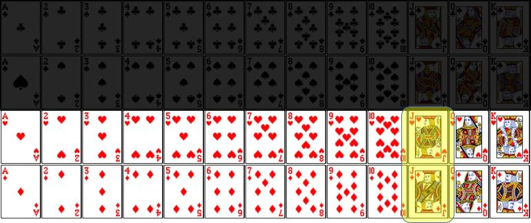

Using Python,

```python
#Find the probability that the card is Red given a prior information that the chosen card is Jack.

P_Jack = 4/52
P_Red = 13/52
P_Jack_n_Red = 2/52


P_Red_given_Jack = P_Jack_n_Red / P_Jack
print('Probability that the card is Red given a prior information that the chosen card is Jack=',P_Red_given_Jack)

#Find the probability that the card is Jack given a prior information that the chosen card is Red.

P_Jack_given_Red = P_Jack_n_Red / P_Red
print('Probability that the card is Jack given a prior information that the chosen card is Red=',P_Jack_given_Red)
```

[output not shown]

**Example 1:**

In a group of 100 buyers, 40 bought shampoo , 30 purchased conditioner, and 10 purchased both Shampoo and Conditioner. If a buyer chosen at random bought shampoo, what is the probability she also bought conditioner?

Soln:

$P(shampoo) = 40/100$

$P(conditioner) = 30/100$

$P(conditioner \; and \; shampoo) = 10/100$

$P(conditioner\; | \;shampoo) = \large {P(conditioner \; and \; shampoo) \over P(shampoo)} = {10/100 \over 40/100}={1 \over 4}$

```python
#using python

P_shampoo = 40/100
P_conditioner = 30/100
P_shampoo_n_conditioner = 10/100

P_conditioner_g_shampoo = P_shampoo_n_conditioner / P_shampoo

print('Probability that she also bought conditioner =',P_conditioner_g_shampoo)
```

```
Probability that she also bought conditioner = 0.25
```

**Example 2:**

This question uses the following contingency table consisting probability of app users by gender:

|  | Use App | Do not use App | Total |
| --- | --- | --- | --- |
| **Male** | 0.41 | 0.08 | 0.49 |
| **Female** | 0.45 | 0.06 | 0.51 |
| **Total** | 0.86 | 0.14 | 1 |

What is the probability a randomly selected person is male, given that he uses the app?

Soln:

$P(male \; | \; uses \; app) = ?$

$P(male \;| \; uses \; app) = \large {P(male \; and \; uses\; app) \over P(uses\; app)}$

From the table given,

$P(male \;| \; uses \; app) = \large{0.41 \over 0.86}=0.47$

```python
#using python

P_male_n_usesapp = 0.41

P_usesapp = 0.86

P_male_g_usesapp = P_male_n_usesapp / P_usesapp

print('Probability a randomly selected person is male, given that he uses the app = ',P_male_g_usesapp)
```

```
Probability a randomly selected person is male, given that he uses the app =  0.4767441860465116
```

**4. Rule of Intersection**

Using the conditional probability of event 𝐴 given the occurrence of event 𝐵, the probability of intersection of event 𝐴 and event 𝐵 is:

$$ {P(A \cap B)} = P(A|B) * P(B) $$

This gives us the fourth basic rule of probability, The Rule of intersection also known as the *Multiplication Rule of probability.*

# 2.3. Independence of Events

Two events $A$ and $B$ are said to be independent of each other if and only if the following three conditions hold:

Conditions for the independence of two events $A$ and $B$:

$$P(A | B) = P(A)$$$$P(B | A) = P(B)$$

and, most useful:

$$P(A \cap B) = P(A)\; P(B)$$

The first two equations have a clear, intuitive appeal. The top equation says that when $A$ and $B$ are independent of each other, then the probability of $A$ stays the same even when we know that $B$ has occurred—it is a simple way of saying that knowledge of $B$ tells us nothing about $A$ when the two events are independent. Similarly, when $A$ and $B$ are independent, then knowledge that $A$ has occurred gives us absolutely no information about $B$ and its likelihood of occurring.

As an example of independent events, consider the following: Suppose I roll a single die. What is the probability that the number 6 will turn up? The answer is $1/6$. Now suppose that I told you that I just tossed a coin and it turned up heads. What is now the probability that the die will show the number 6? The answer is unchanged, $1/6$, because events of the die and the coin are independent of each other. We see that $P(6 | H) = P(6)$, which is the first rule above.

The third equation, however, is the most useful in applications. It tells us that when $A$ and $B$ are independent (and only when they are independent), we can obtain the probability of the joint occurrence of $A$ and $B$ (i.e., the probability of their intersection or Joint Probability of events A and B.) simply by multiplying the two separate probabilities. This rule is thus called the *product rule for independent events.* (The rule is easily derived from the first rule, using the definition of conditional probability.)

### Example :

Consider the following **Joint Probability Table :**

|  | Engine | Gearbox |
| --- | --- | --- |
| Fails | 0.01 | 0.005 |
| Works | 0.99 | 0.995 |

Find the probability that the Engine and Gear Box both fails.

P(Engine Fails) = 0.01

```python
#using python

P_Eng_fail = 0.01
P_GearB_fail = 0.005
P_both_fails = P_Eng_fail*P_GearB_fail
print('Probability that the Engine and Gear Box both fails =',P_both_fails)
```

```
Probability that the Engine and Gear Box both fails = 5e-05
```

```python
#supressing scientific format for output

print('Probability that the Engine and Gear Box both fails =',"{:.5f}".format(P_both_fails))
```

```
Probability that the Engine and Gear Box both fails = 0.00005
```

### Independent Events are not affected by previous events:

As an example, consider flipping a coin. When flipping a coin, the probability of getting a head does not change no matter how many times you flip the coin. For example, when flipping a coin four consecutive times, and the first three flips are heads, the fourth flip still has the probability $ 1/2 $. Thus,

The probability of getting four heads = $\large{1 \over 2} * {1 \over 2} * {1 \over 2} * {1 \over 2} = {1 \over 16} $

*'A coin does not "know" it came up heads before and each toss of a coin is a perfect isolated thing.'*

### Example of Dependent Events:

If the cards are not replaced into the deck, then probabilities change depending on which cards have been drawn. For example, the probability of drawing an ace from a standard deck of 52 cards is 4/52 or 1/13. However, if the first draw results an ace, the probability that the second draw will also be an ace is now 3/51, **if the first ace is not replaced into the deck.**